# students_alcohol

### Caso de Estudio: Alcohol en Estudiantes

Para este caso cuento con un dataset de estudiantes del curso de matemáticas y un dataset de estudiantes del curso de lengua portuguesa. Se explorará el dataset en busqueda de patrones para las conclusiones iniciales, transformaciones necesarias y visualizaciones de descripción de los datos. Buscamos encontrar las variables que puedan explicar el consumo de alcohol en semana y los fines de semana, y si el consumo de alcohol afecta las notas en los periodos académicos.

```python
# importar las librerías necesarias

import numpy as np
import matplotlib.pyplot as plt
import pandas as pd
import seaborn as sns
import warnings

# ignorar los mensajes de advertencia

warnings.filterwarnings("ignore")

# setear el estilo de los gráficos

sns.set(style="whitegrid", palette="muted")
```

```python
# importar los dataset de trabajo

math_df = pd.read_csv('./data_raw/student-mat.csv')
port_df = pd.read_csv('./data_raw/student-por.csv')
```

```python
# revisar los datos

math_df.head()
```

|  | school | sex | age | address | famsize | Pstatus | Medu | Fedu | Mjob | Fjob | ... | famrel | freetime | goout | Dalc | Walc | health | absences | G1 | G2 | G3 |
| --- | --- | --- | --- | --- | --- | --- | --- | --- | --- | --- | --- | --- | --- | --- | --- | --- | --- | --- | --- | --- | --- |
| 0 | GP | F | 18 | U | GT3 | A | 4 | 4 | at_home | teacher | ... | 4 | 3 | 4 | 1 | 1 | 3 | 6 | 5 | 6 | 6 |
| 1 | GP | F | 17 | U | GT3 | T | 1 | 1 | at_home | other | ... | 5 | 3 | 3 | 1 | 1 | 3 | 4 | 5 | 5 | 6 |
| 2 | GP | F | 15 | U | LE3 | T | 1 | 1 | at_home | other | ... | 4 | 3 | 2 | 2 | 3 | 3 | 10 | 7 | 8 | 10 |
| 3 | GP | F | 15 | U | GT3 | T | 4 | 2 | health | services | ... | 3 | 2 | 2 | 1 | 1 | 5 | 2 | 15 | 14 | 15 |
| 4 | GP | F | 16 | U | GT3 | T | 3 | 3 | other | other | ... | 4 | 3 | 2 | 1 | 2 | 5 | 4 | 6 | 10 | 10 |

5 rows × 33 columns

```python
port_df.head()
```

|  | school | sex | age | address | famsize | Pstatus | Medu | Fedu | Mjob | Fjob | ... | famrel | freetime | goout | Dalc | Walc | health | absences | G1 | G2 | G3 |
| --- | --- | --- | --- | --- | --- | --- | --- | --- | --- | --- | --- | --- | --- | --- | --- | --- | --- | --- | --- | --- | --- |
| 0 | GP | F | 18 | U | GT3 | A | 4 | 4 | at_home | teacher | ... | 4 | 3 | 4 | 1 | 1 | 3 | 4 | 0 | 11 | 11 |
| 1 | GP | F | 17 | U | GT3 | T | 1 | 1 | at_home | other | ... | 5 | 3 | 3 | 1 | 1 | 3 | 2 | 9 | 11 | 11 |
| 2 | GP | F | 15 | U | LE3 | T | 1 | 1 | at_home | other | ... | 4 | 3 | 2 | 2 | 3 | 3 | 6 | 12 | 13 | 12 |
| 3 | GP | F | 15 | U | GT3 | T | 4 | 2 | health | services | ... | 3 | 2 | 2 | 1 | 1 | 5 | 0 | 14 | 14 | 14 |
| 4 | GP | F | 16 | U | GT3 | T | 3 | 3 | other | other | ... | 4 | 3 | 2 | 1 | 2 | 5 | 0 | 11 | 13 | 13 |

5 rows × 33 columns

```python
# revisar los tipos y la cantidad de datos

math_df.info()
```

```
<class 'pandas.core.frame.DataFrame'>
RangeIndex: 395 entries, 0 to 394
Data columns (total 33 columns):
 #   Column      Non-Null Count  Dtype
---  ------      --------------  -----
 0   school      395 non-null    object
 1   sex         395 non-null    object
 2   age         395 non-null    int64
 3   address     395 non-null    object
 4   famsize     395 non-null    object
 5   Pstatus     395 non-null    object
 6   Medu        395 non-null    int64
 7   Fedu        395 non-null    int64
 8   Mjob        395 non-null    object
 9   Fjob        395 non-null    object
```

[output cut: 25 more lines]

```python
port_df.info()
```

```
<class 'pandas.core.frame.DataFrame'>
RangeIndex: 649 entries, 0 to 648
Data columns (total 33 columns):
 #   Column      Non-Null Count  Dtype
---  ------      --------------  -----
 0   school      649 non-null    object
 1   sex         649 non-null    object
 2   age         649 non-null    int64
 3   address     649 non-null    object
 4   famsize     649 non-null    object
 5   Pstatus     649 non-null    object
 6   Medu        649 non-null    int64
 7   Fedu        649 non-null    int64
 8   Mjob        649 non-null    object
 9   Fjob        649 non-null    object
```

[output cut: 25 more lines]

```python
# revisar datos duplicados

math_df.duplicated().sum()
```

```
np.int64(0)
```

```python
port_df.duplicated().sum()
```

```
np.int64(0)
```

```python
# revisar la estadística descriptiva

math_df.describe()
```

|  | age | Medu | Fedu | traveltime | studytime | failures | famrel | freetime | goout | Dalc | Walc | health | absences | G1 | G2 | G3 |
| --- | --- | --- | --- | --- | --- | --- | --- | --- | --- | --- | --- | --- | --- | --- | --- | --- |
| count | 395.000000 | 395.000000 | 395.000000 | 395.000000 | 395.000000 | 395.000000 | 395.000000 | 395.000000 | 395.000000 | 395.000000 | 395.000000 | 395.000000 | 395.000000 | 395.000000 | 395.000000 | 395.000000 |
| mean | 16.696203 | 2.749367 | 2.521519 | 1.448101 | 2.035443 | 0.334177 | 3.944304 | 3.235443 | 3.108861 | 1.481013 | 2.291139 | 3.554430 | 5.708861 | 10.908861 | 10.713924 | 10.415190 |
| std | 1.276043 | 1.094735 | 1.088201 | 0.697505 | 0.839240 | 0.743651 | 0.896659 | 0.998862 | 1.113278 | 0.890741 | 1.287897 | 1.390303 | 8.003096 | 3.319195 | 3.761505 | 4.581443 |
| min | 15.000000 | 0.000000 | 0.000000 | 1.000000 | 1.000000 | 0.000000 | 1.000000 | 1.000000 | 1.000000 | 1.000000 | 1.000000 | 1.000000 | 0.000000 | 3.000000 | 0.000000 | 0.000000 |
| 25% | 16.000000 | 2.000000 | 2.000000 | 1.000000 | 1.000000 | 0.000000 | 4.000000 | 3.000000 | 2.000000 | 1.000000 | 1.000000 | 3.000000 | 0.000000 | 8.000000 | 9.000000 | 8.000000 |
| 50% | 17.000000 | 3.000000 | 2.000000 | 1.000000 | 2.000000 | 0.000000 | 4.000000 | 3.000000 | 3.000000 | 1.000000 | 2.000000 | 4.000000 | 4.000000 | 11.000000 | 11.000000 | 11.000000 |
| 75% | 18.000000 | 4.000000 | 3.000000 | 2.000000 | 2.000000 | 0.000000 | 5.000000 | 4.000000 | 4.000000 | 2.000000 | 3.000000 | 5.000000 | 8.000000 | 13.000000 | 13.000000 | 14.000000 |
| max | 22.000000 | 4.000000 | 4.000000 | 4.000000 | 4.000000 | 3.000000 | 5.000000 | 5.000000 | 5.000000 | 5.000000 | 5.000000 | 5.000000 | 75.000000 | 19.000000 | 19.000000 | 20.000000 |

```python
port_df.describe()
```

|  | age | Medu | Fedu | traveltime | studytime | failures | famrel | freetime | goout | Dalc | Walc | health | absences | G1 | G2 | G3 |
| --- | --- | --- | --- | --- | --- | --- | --- | --- | --- | --- | --- | --- | --- | --- | --- | --- |
| count | 649.000000 | 649.000000 | 649.000000 | 649.000000 | 649.000000 | 649.000000 | 649.000000 | 649.000000 | 649.000000 | 649.000000 | 649.000000 | 649.000000 | 649.000000 | 649.000000 | 649.000000 | 649.000000 |
| mean | 16.744222 | 2.514638 | 2.306626 | 1.568567 | 1.930663 | 0.221880 | 3.930663 | 3.180277 | 3.184900 | 1.502311 | 2.280431 | 3.536210 | 3.659476 | 11.399076 | 11.570108 | 11.906009 |
| std | 1.218138 | 1.134552 | 1.099931 | 0.748660 | 0.829510 | 0.593235 | 0.955717 | 1.051093 | 1.175766 | 0.924834 | 1.284380 | 1.446259 | 4.640759 | 2.745265 | 2.913639 | 3.230656 |
| min | 15.000000 | 0.000000 | 0.000000 | 1.000000 | 1.000000 | 0.000000 | 1.000000 | 1.000000 | 1.000000 | 1.000000 | 1.000000 | 1.000000 | 0.000000 | 0.000000 | 0.000000 | 0.000000 |
| 25% | 16.000000 | 2.000000 | 1.000000 | 1.000000 | 1.000000 | 0.000000 | 4.000000 | 3.000000 | 2.000000 | 1.000000 | 1.000000 | 2.000000 | 0.000000 | 10.000000 | 10.000000 | 10.000000 |
| 50% | 17.000000 | 2.000000 | 2.000000 | 1.000000 | 2.000000 | 0.000000 | 4.000000 | 3.000000 | 3.000000 | 1.000000 | 2.000000 | 4.000000 | 2.000000 | 11.000000 | 11.000000 | 12.000000 |
| 75% | 18.000000 | 4.000000 | 3.000000 | 2.000000 | 2.000000 | 0.000000 | 5.000000 | 4.000000 | 4.000000 | 2.000000 | 3.000000 | 5.000000 | 6.000000 | 13.000000 | 13.000000 | 14.000000 |
| max | 22.000000 | 4.000000 | 4.000000 | 4.000000 | 4.000000 | 3.000000 | 5.000000 | 5.000000 | 5.000000 | 5.000000 | 5.000000 | 5.000000 | 32.000000 | 19.000000 | 19.000000 | 19.000000 |

```python
# revisar la descripción de las variables categóricas

math_df.describe(include='object')
```

|  | school | sex | address | famsize | Pstatus | Mjob | Fjob | reason | guardian | schoolsup | famsup | paid | activities | nursery | higher | internet | romantic |
| --- | --- | --- | --- | --- | --- | --- | --- | --- | --- | --- | --- | --- | --- | --- | --- | --- | --- |
| count | 395 | 395 | 395 | 395 | 395 | 395 | 395 | 395 | 395 | 395 | 395 | 395 | 395 | 395 | 395 | 395 | 395 |
| unique | 2 | 2 | 2 | 2 | 2 | 5 | 5 | 4 | 3 | 2 | 2 | 2 | 2 | 2 | 2 | 2 | 2 |
| top | GP | F | U | GT3 | T | other | other | course | mother | no | yes | no | yes | yes | yes | yes | no |
| freq | 349 | 208 | 307 | 281 | 354 | 141 | 217 | 145 | 273 | 344 | 242 | 214 | 201 | 314 | 375 | 329 | 263 |

```python
port_df.describe(include='object')
```

|  | school | sex | address | famsize | Pstatus | Mjob | Fjob | reason | guardian | schoolsup | famsup | paid | activities | nursery | higher | internet | romantic |
| --- | --- | --- | --- | --- | --- | --- | --- | --- | --- | --- | --- | --- | --- | --- | --- | --- | --- |
| count | 649 | 649 | 649 | 649 | 649 | 649 | 649 | 649 | 649 | 649 | 649 | 649 | 649 | 649 | 649 | 649 | 649 |
| unique | 2 | 2 | 2 | 2 | 2 | 5 | 5 | 4 | 3 | 2 | 2 | 2 | 2 | 2 | 2 | 2 | 2 |
| top | GP | F | U | GT3 | T | other | other | course | mother | no | yes | no | no | yes | yes | yes | no |
| freq | 423 | 383 | 452 | 457 | 569 | 258 | 367 | 285 | 455 | 581 | 398 | 610 | 334 | 521 | 580 | 498 | 410 |

```python
# concatenar los dos dataframes

df = pd.concat([math_df, port_df])
```

```python
# quitar los registros duplicados solo con las columnas de interés

df = df.drop_duplicates(subset=['school', 'sex', 'age', 'address', 'famsize', 'Pstatus', 'Medu', 'Fedu',
       'Mjob', 'Fjob', 'reason', 'guardian'])
```

```python
df.info()
```

```
<class 'pandas.core.frame.DataFrame'>
Index: 661 entries, 0 to 642
Data columns (total 33 columns):
 #   Column      Non-Null Count  Dtype
---  ------      --------------  -----
 0   school      661 non-null    object
 1   sex         661 non-null    object
 2   age         661 non-null    int64
 3   address     661 non-null    object
 4   famsize     661 non-null    object
 5   Pstatus     661 non-null    object
 6   Medu        661 non-null    int64
 7   Fedu        661 non-null    int64
 8   Mjob        661 non-null    object
 9   Fjob        661 non-null    object
```

[output cut: 25 more lines]

### Análisis inicial

- El df del curso de matemáticas tiene 395 registros, mientras que el df del curso de portugues 649 registros
- En ambos df encontramos 16 columnas numéricas y 17 categóricas
- Al unir ambos dataset y quitar los duplicados quedan 661 registros únicos, con los que se realizará el EDA a continuación

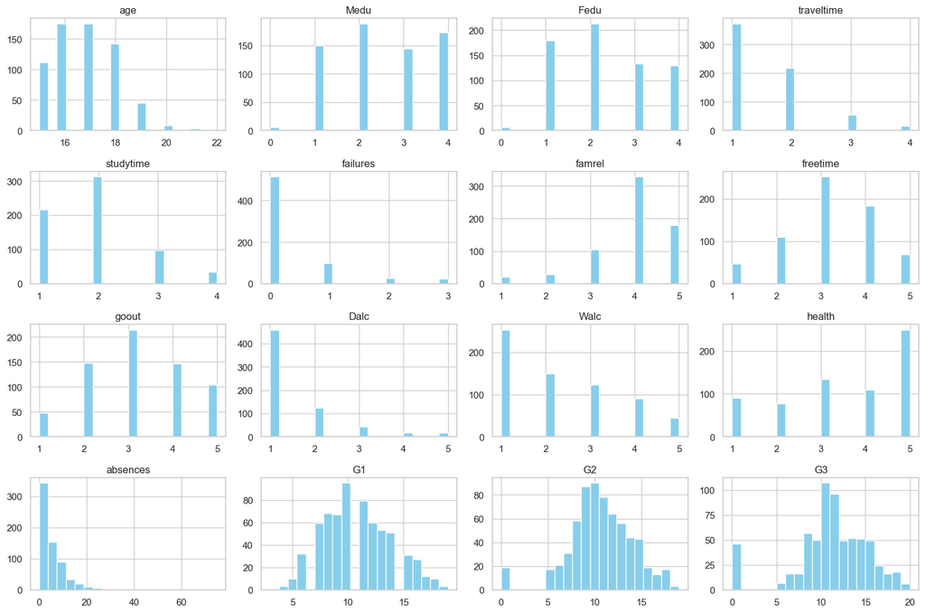

```python
# graficar la distribución de las variables numéricas con seaborn en una sola vista

df.hist(figsize=(15, 10), bins=20, color='skyblue')
plt.tight_layout()
plt.show()
```

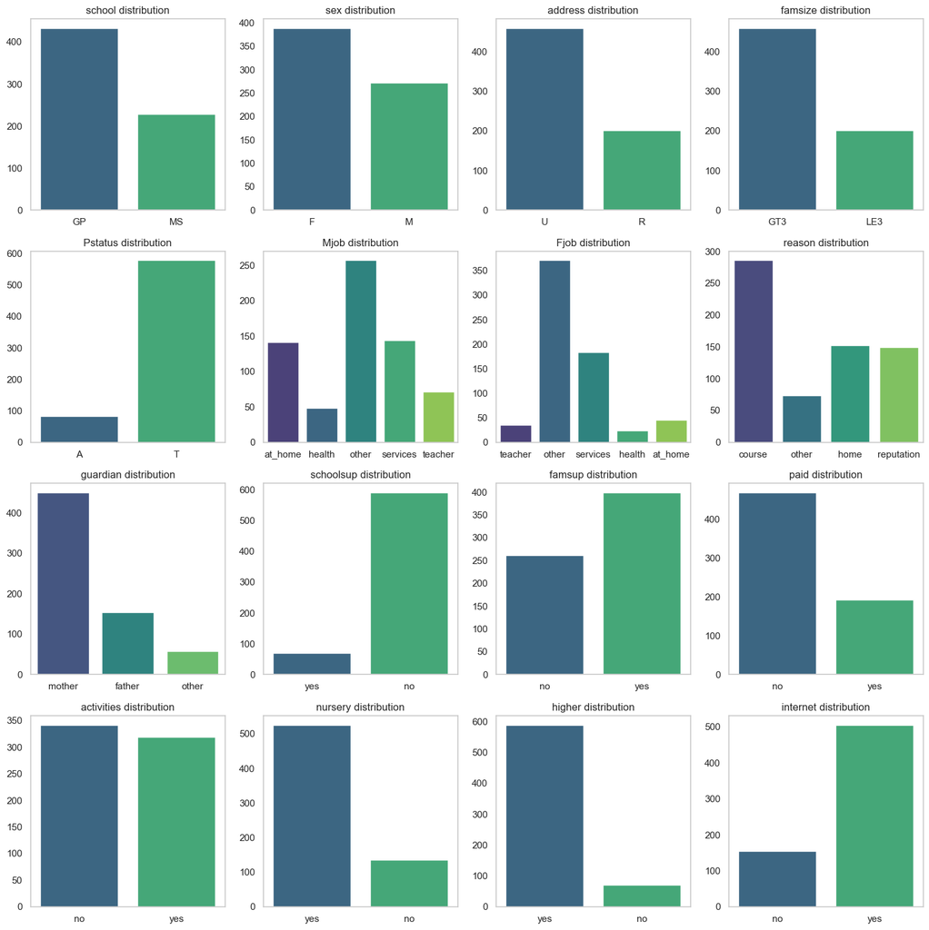

```python
# graficar la distribución de las variables categóricas con seaborn en una sola vista

df_cat = df.select_dtypes(include='object')

fig, axes = plt.subplots(4, 4, figsize=(15, 15))
axes = axes.flatten()

for i, col in enumerate(df_cat.columns):
    if i < len(axes):
        sns.countplot(x=col, data=df_cat, ax=axes[i], palette='viridis')
        axes[i].set_title(f'{col} distribution')
        axes[i].set_xlabel('')
        axes[i].set_ylabel('')
        axes[i].grid(axis='y')

plt.tight_layout()
plt.show();
```

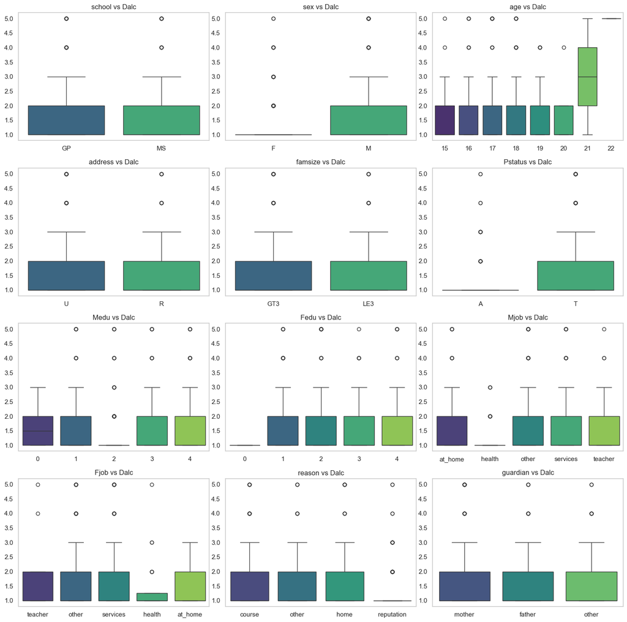

```python
# graficar la interacción las variables y el consumo de alcohol en días laborales Dalc en una sola vista con seaborn

variables = ['school', 'sex', 'age', 'address', 'famsize', 'Pstatus', 'Medu', 'Fedu',
       'Mjob', 'Fjob', 'reason', 'guardian']

fig, axes = plt.subplots(4, 3, figsize=(15, 15))
axes = axes.flatten()

for i, col in enumerate(variables):
       if i < len(axes):
              sns.boxplot(x=col, y='Dalc', data=df, ax=axes[i], palette='viridis')
              axes[i].set_title(f'{col} vs Dalc')
              axes[i].set_xlabel('')
              axes[i].set_ylabel('')
              axes[i].grid(axis='y')

plt.tight_layout()
plt.show();
```